# Extra Exercises

Mark Dunning

Last modified: 06 Oct 2016

# Extra exercises

## Gapminder

We will investigate the [gapminder](https://www.gapminder.org/data/) dataset using ggplot2 and dplyr. If you have followed our [‘crash-course’](https://bioinformatics-core-shared-training.github.io/r-crash-course/) these data should be familiar to you. In brief, these data give various indicator variables for different countries around the world (life expectancy, population and Gross Domestic Product). A subset of this large dataset are available in the [`gapminder` package](https://github.com/jennybc/gapminder), but we have saved these data as a .csv file to demonstrate how to import data into R.

```r
library(dplyr)
gapminder <- read.csv("gapminder.csv") %>% tbl_df
gapminder
```

```
## # A tibble: 1,704 × 6
##        country continent  year lifeExp      pop gdpPercap
##         <fctr>    <fctr> <int>   <dbl>    <int>     <dbl>
## 1  Afghanistan      Asia  1952  28.801  8425333  779.4453
## 2  Afghanistan      Asia  1957  30.332  9240934  820.8530
## 3  Afghanistan      Asia  1962  31.997 10267083  853.1007
## 4  Afghanistan      Asia  1967  34.020 11537966  836.1971
## 5  Afghanistan      Asia  1972  36.088 13079460  739.9811
## 6  Afghanistan      Asia  1977  38.438 14880372  786.1134
## 7  Afghanistan      Asia  1982  39.854 12881816  978.0114
## 8  Afghanistan      Asia  1987  40.822 13867957  852.3959
## 9  Afghanistan      Asia  1992  41.674 16317921  649.3414
## 10 Afghanistan      Asia  1997  41.763 22227415  635.3414
## # ... with 1,694 more rows
```

As an example of the ‘canvas-model’ of base graphics we saw how to plot the relationship between life expectancy and gdp for african and european countries on the same graph using `points`.

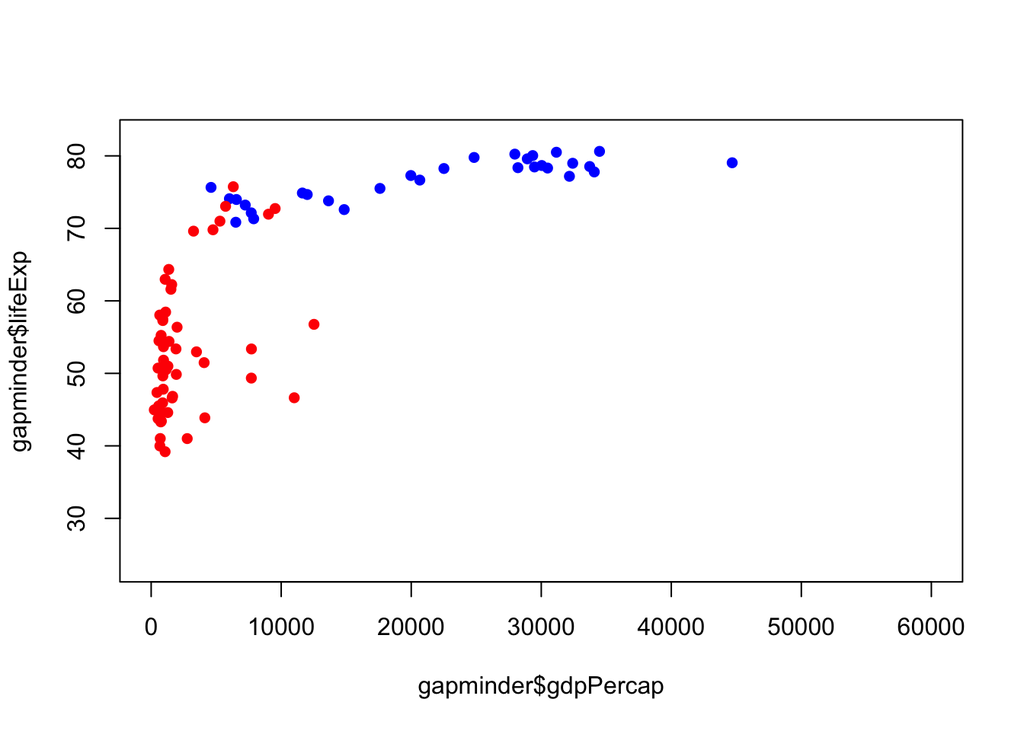

Try and replicate the plots and tables shown here. Use ‘piping’ to set out your answers.

1. Try the same plot with `ggplot2`

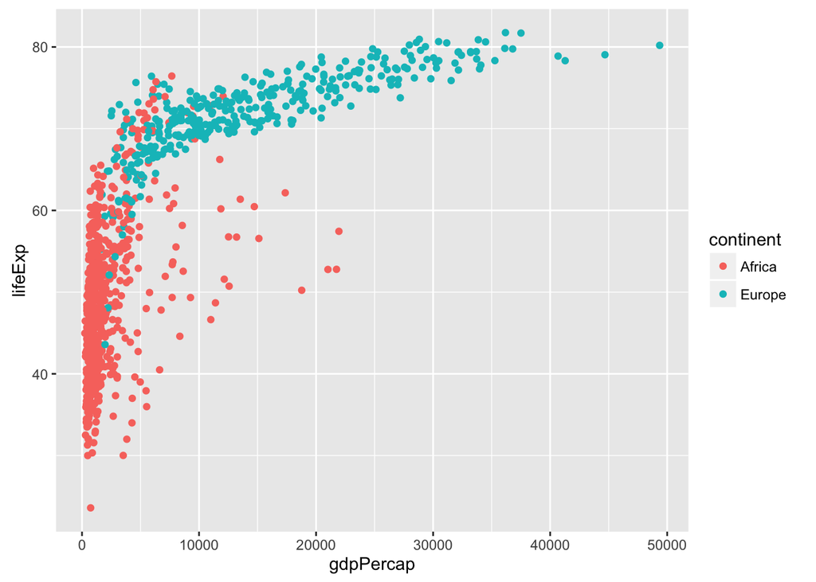

2. Rather than just Europe and Africa, can you plot all continents?

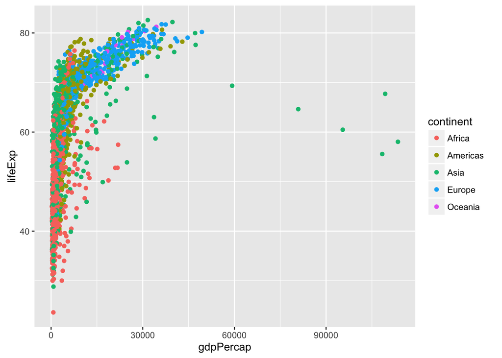

3. The graph looks a bit cluttered perhaps? If we wanted to compare trends between continents, we could add some `facet`ting

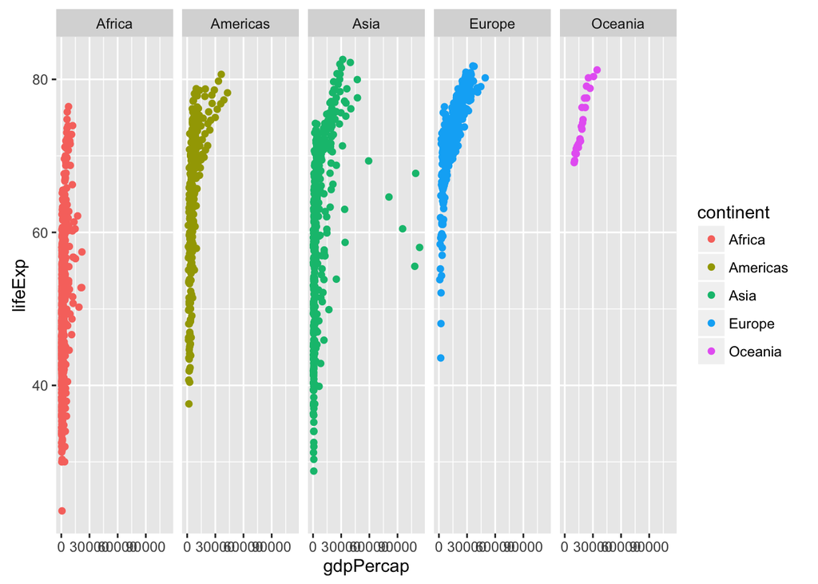

4. Breaking the graph down per-year, per-continent?

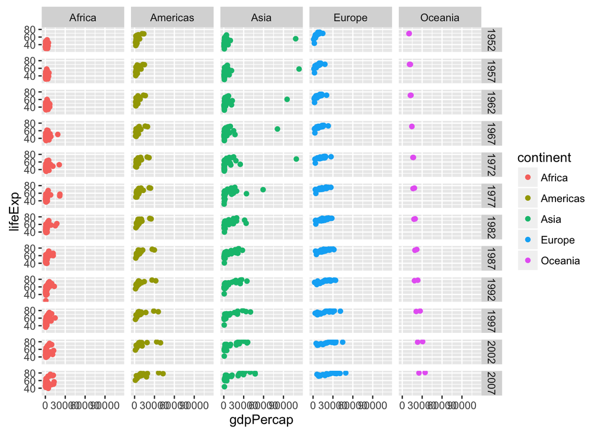

5. (just for fun!) Countries in the Americas, years 1992 to 2007, labelled by name, size of points in millions of people

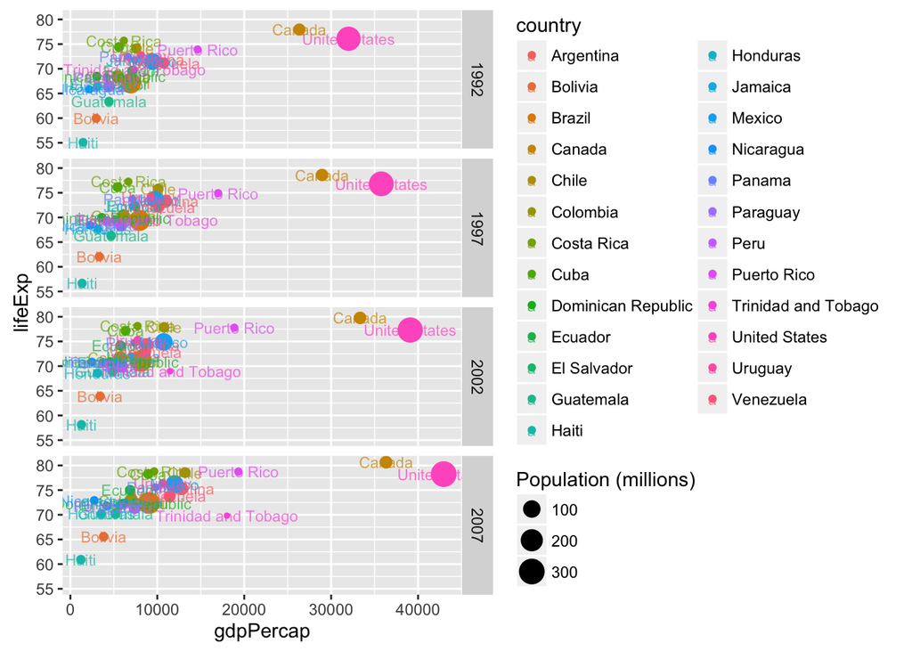

6. Has life expectancy increased with time?
- recall that categorical variables are required for `geom_boxplot`….

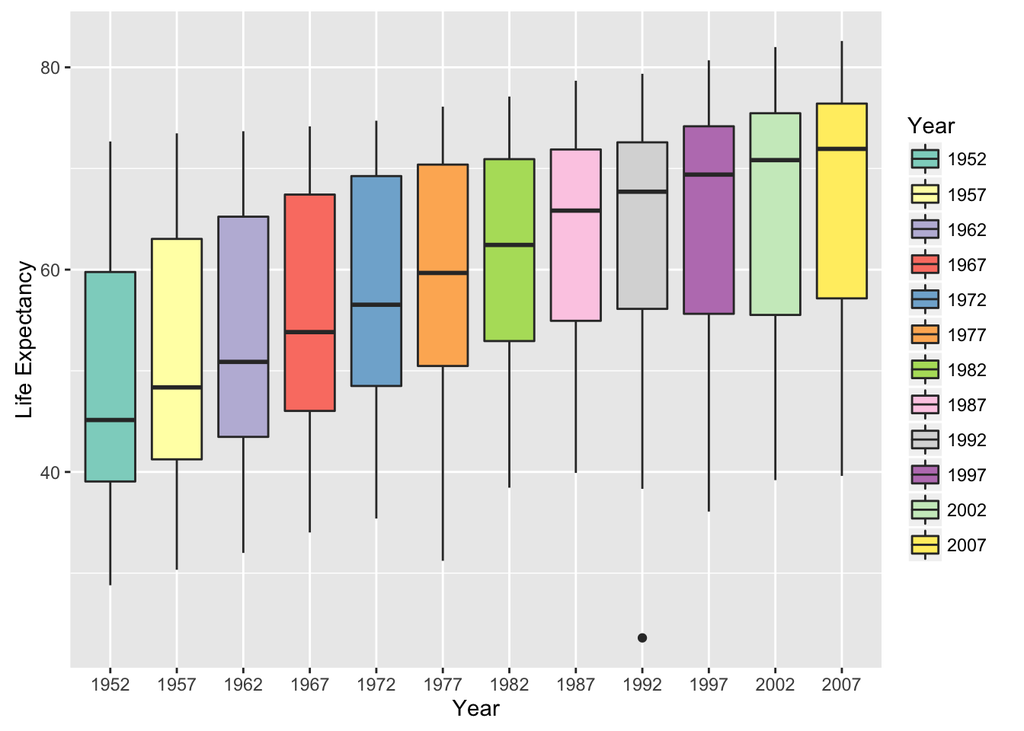

7. There is an apparent outlier in 1992 with very low life expectancy. What country does this correspond to?
8. Is the trend consistent with different continents? Can you produce the following plot which excludes Oceania?

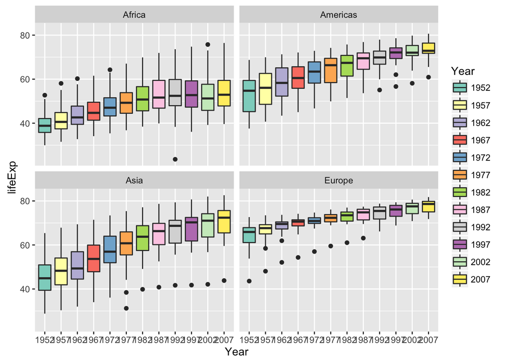

9. Can you arrange the panels to be in the order Europe, Americas, Asia, Africa?
- HINT: when creating a factor, you have the chance to specify the `levels`

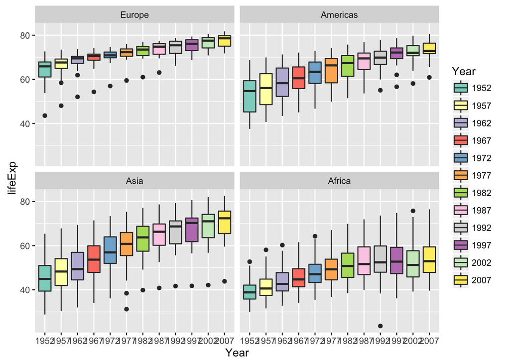

9b. Similar to above, but with individual points and a smoothed line to show trend - for this exampleß, for `geom_point` you will need to be working with continuous values of `year`

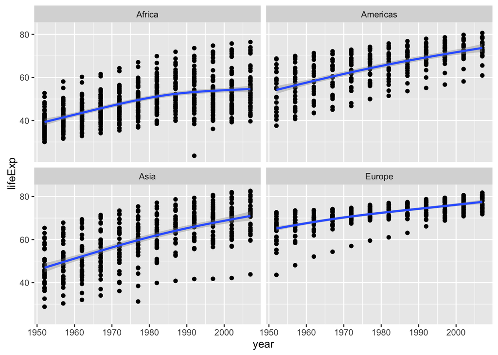

10. For each year, which country in each continent had the lowest life expectancy.
    - write the data frame as a `.csv` file.

```
## Source: local data frame [6 x 6]
## Groups: year [2]
##
##    year continent      country lifeExp      pop  gdpPercap
##   <int>    <fctr>       <fctr>   <dbl>    <int>      <dbl>
## 1  1952    Africa       Gambia  30.000   284320   485.2307
## 2  1952  Americas        Haiti  37.579  3201488  1840.3669
## 3  1952      Asia  Afghanistan  28.801  8425333   779.4453
## 4  1952    Europe       Turkey  43.585 22235677  1969.1010
## 5  1952   Oceania    Australia  69.120  8691212 10039.5956
## 6  1957    Africa Sierra Leone  31.570  2295678  1004.4844
```

11. For each continent, find the country with the highest correlation between life expectancy and year

```
## # A tibble: 5 × 3
##   continent    country Correlation
##      <fctr>     <fctr>       <dbl>
## 1    Africa Mauritania   0.9988365
## 2  Americas     Brazil   0.9990232
## 3      Asia   Pakistan   0.9986239
## 4    Europe     France   0.9988116
## 5   Oceania  Australia   0.9897716
```

12. For the countries with the lowest correlation in each continent, plot the relationship between life expectancy and year

```
## # A tibble: 5 × 3
##   continent             country Correlation
##      <fctr>              <fctr>       <dbl>
## 1    Africa              Zambia  -0.2446149
## 2  Americas Trinidad and Tobago   0.8933126
## 3      Asia                Iraq   0.7387721
## 4    Europe            Bulgaria   0.7392849
## 5   Oceania         New Zealand   0.9765166
```

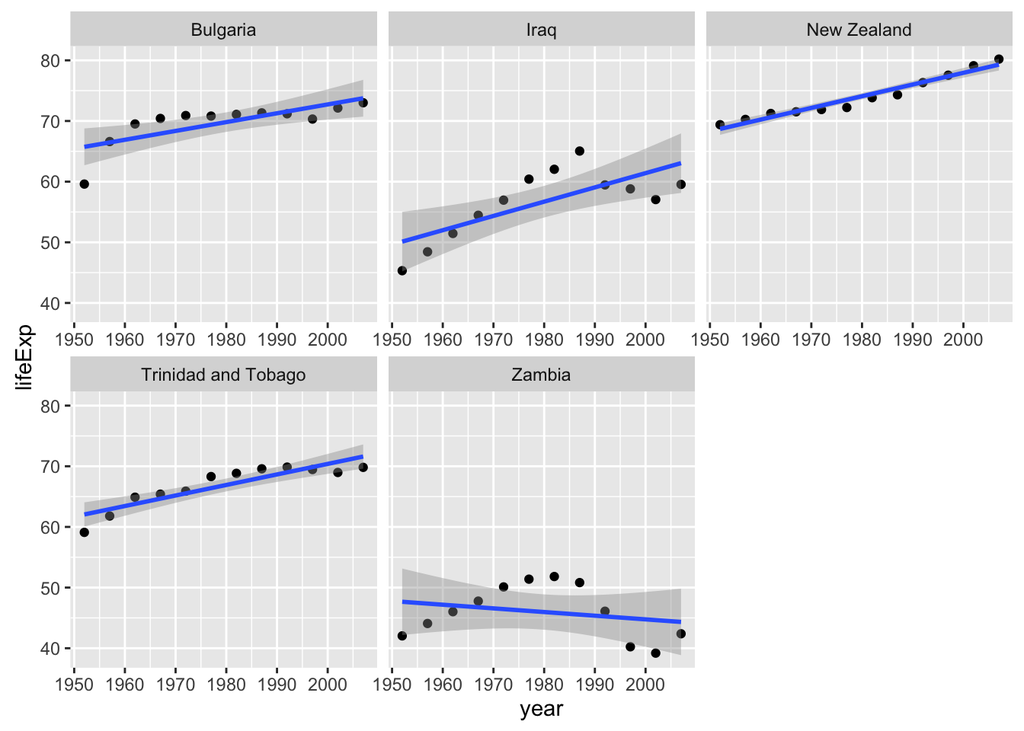